# Tema 5. Operaciones con datos vectoriales en sf

Programación en Tecnologías de la Información Geográfica · Máster Universitario en Tecnologías de la Información Geográfica

Author

Paloma Ruiz Benito y Verónica Cruz Alonso

Published

30/10/2026

[figure not shown]

En este tema vamos a trabajar con datos vectoriales con el paquete **sf**:

[figure not shown]

Para más información visita la web https://r-spatial.github.io/sf/, en la que nos hemos centrado para preparar el material.

Libros de referencia:

https://r-spatial.org/book/

[figure not shown]

https://r.geocompx.org/

[figure not shown]

**sf** viene de *“**simple features**”,* una forma sencilla de trabajar con datos espaciales, ya que no es más que un *data frame* (i.e. los atributos), con la información geométrica (i.e. información espacial incluyendo el sistema de proyección).

## 1 Simple features o “entidades simples” y su implementación en R

*“Simple features”* se refiere a un estandar formal (ISO 19125-1:2004) que describe cómo objetos del mundo real pueden representarse en los ordenadores, con énfasis a la geometría espacial de estos objetos. También incluye cómo pueden guardarse y almacenarse los objetos, así como las operaciones geométricas que pueden hacerse con ellos.

Las entidades o “*features*” a las que se refiere el [paquete **`sf`**](https://journal.r-project.org/articles/RJ-2018-009/index.html) pueden ser consideradas como cosas u objetos que tienen una determinada localización espacial o extensión (es decir, su **geometría**), que pueden ser descrita por puntos, lineas, poligonos o combinaciones de estos. El *simple* se refiere a que las líneas o polígonos están construidos por puntos que se conectan por lineas rectas. Además, cada elemento tiene una serie de *atributos* o propiedades, que son características o variables que se añaden a cada unidad de observación. Este paquete está estandarizado en el formato `tidyverse`, y se usa comunmente con paquetes como **`dplyr`** o **`ggplot2`**, que hemos usado en el curso.

Una *entidad simple* se define en la especificación abstracta de OpenGIS como un elemento que tiene **atributos espaciales** y **no espaciales**. Los atributos espaciales son de tipo **geometría**, y los **no espaciales** se basan en geometrías 2D con interpolación lineal entre vértices.

En R los objetos espaciales son simplemente objetos y todas las funciones espaciales se inician con “*st_”* que se refiere a un”*spatial type*” o “*tipo espacial*” y hace que la forma de completar el código sea sencillo. La gestión de datos espaciales requiere la lectura de datos espaciales, la manipilación y escritura de los resultados.

En primer lugar, podríamos leer unos datos:

```r
library(tidyverse)
library(sf)
nc <- st_read(system.file("shape/nc.shp", package = "sf"))
class(nc)
```

```
[1] "sf"         "data.frame"
```

```r
print(nc, n = 3)
```

```
Simple feature collection with 100 features and 14 fields
Geometry type: MULTIPOLYGON
Dimension:     XY
Bounding box:  xmin: -84.32385 ymin: 33.88199 xmax: -75.45698 ymax: 36.58965
Geodetic CRS:  NAD27
First 3 features:
   AREA PERIMETER CNTY_ CNTY_ID      NAME  FIPS FIPSNO CRESS_ID BIR74 SID74
1 0.114     1.442  1825    1825      Ashe 37009  37009        5  1091     1
2 0.061     1.231  1827    1827 Alleghany 37005  37005        3   487     0
3 0.143     1.630  1828    1828     Surry 37171  37171       86  3188     5
  NWBIR74 BIR79 SID79 NWBIR79                       geometry
1      10  1364     0      19 MULTIPOLYGON (((-81.47276 3...
2      10   542     3      12 MULTIPOLYGON (((-81.23989 3...
3     208  3616     6     260 MULTIPOLYGON (((-80.45634 3...
```

Normalmente, los usuarios no usan la función *“system file”* sino que propocionan directamente un nombre de archivo. Al ver el tipo de objeto, se puede ver como es un “data.frame” con una columna tipo lista con la geometría.

Cuando imprimimos la base de datos, vemos cada columna es cada atributo dentro de la geometría. Podríamos crear un objeto tipo data.frame a partir del objetio tipo `sf`, pero en ese caso pierde la columa de geometría (que es tipo lista), no podemos hacer un gráfico y no podemos hacer todos los métodos de análisis espacial que se pueden hacer con un objeto tipo `sf`.

```r
nc.no_sf <- as.data.frame(nc)
class(nc.no_sf)
```

```
[1] "data.frame"
```

Para ver todas las funciones que se pueden usar con formato `sf`, podemos verlo de la siguiente manera:

```r
methods(class = "sf")
```

```
  [1] $<-                          [
  [3] [[<-                         [<-
  [5] aggregate                    anti_join
  [7] arrange                      as.data.frame
  [9] cbind                        coerce
 [11] count                        dbDataType
 [13] dbWriteTable                 distinct
 [15] dplyr_reconstruct            drop_na
 [17] duplicated                   filter
 [19] full_join                    gather
 [21] group_by                     group_split
 [23] identify                     initialize
 [25] inner_join                   left_join
 [27] merge                        mutate
 [29] nest                         pivot_longer
```

[output cut: 45 more lines]

## 2 Coordenadas

**Tip**

*Data are not just numbers, they are numbers with a context; in data analysis, context provides meaning* ([Cobb and Moore 1997](https://r-spatial.org/book/references.html#ref-cobbmoore))

Para información espacial, la localización se caracteriza mediante **coordenadas** y estas coordenadas se definen mediante un sistema espacial. La mayor diferencia es si las coordenadas son cartesianas (es decir, definidas en un espacio de dos o tres dimensiones respecto a ejes ortogonales) o polar, esférico o elipsoidal (es decir, usando las distancias o direcciones).

Además, las coordenadas generalmente tienen dos dimensiones X e Y (longitud y latitud), pero podrían tener una tercera Z (altitud) e incluso una cuarta M que es raramente usada pero que se refiere a alguna medida asociada con el punto (no con la entidad, ya que sino sería un atributo).

Con esta información, los tipos de geometría son:

[output not shown]

Las coordenadas solo pueden ubicarse en la superficie de la Tierra cuando se conoce su **sistema de referencia de coordenadas (CRS)**; este puede ser un CRS esferoidal como WGS84, un CRS proyectado y bidimensional (cartesiano) como una zona UTM o Web Mercator, o un CRS tridimensional o que incluya el tiempo.

En un objeto tipo `sf` la columna de tipo lista, es de clase `sf` y se puede obtener con la función `st_geometry()`:

```r
nc_geom <- st_geometry(nc) #seleccionamos las geometrias
nc_geom[[1]] #para ver una geometría completa seleccionando el primero.
```

```
MULTIPOLYGON (((-81.47276 36.23436, -81.54084 36.27251, -81.56198 36.27359, -81.63306 36.34069, -81.74107 36.39178, -81.69828 36.47178, -81.7028 36.51934, -81.67 36.58965, -81.3453 36.57286, -81.34754 36.53791, -81.32478 36.51368, -81.31332 36.4807, -81.26624 36.43721, -81.26284 36.40504, -81.24069 …
```

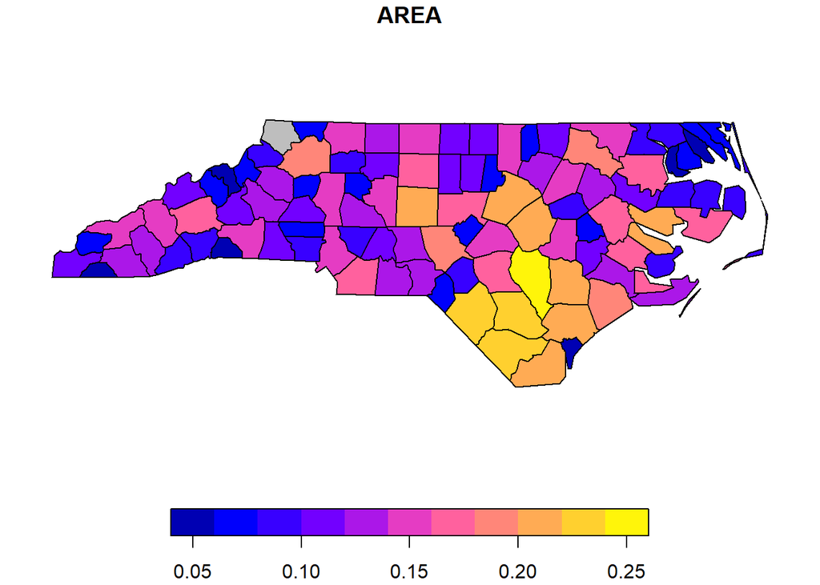

```r
par(mar = c(0,0,1,0))

plot(nc[1], reset = FALSE) # reset = FALSE: queremos añadir un plot con una leyenda
plot(nc[1,1], col = 'grey', add = TRUE)
```

Las transformaciones en el código se realizan con la función `st_transform()`. Por ejemplo se pueden transformar las coordenadas de NAD27 a WGS84.

```r
nc_wgs84 <- st_transform(nc, 4326)   # o "EPSG:4326"
nc_wgs84
```

```
Simple feature collection with 100 features and 14 fields
Geometry type: MULTIPOLYGON
Dimension:     XY
Bounding box:  xmin: -84.32377 ymin: 33.88212 xmax: -75.45662 ymax: 36.58973
Geodetic CRS:  WGS 84
First 10 features:
    AREA PERIMETER CNTY_ CNTY_ID        NAME  FIPS FIPSNO CRESS_ID BIR74 SID74
1  0.114     1.442  1825    1825        Ashe 37009  37009        5  1091     1
2  0.061     1.231  1827    1827   Alleghany 37005  37005        3   487     0
3  0.143     1.630  1828    1828       Surry 37171  37171       86  3188     5
4  0.070     2.968  1831    1831   Currituck 37053  37053       27   508     1
5  0.153     2.206  1832    1832 Northampton 37131  37131       66  1421     9
6  0.097     1.670  1833    1833    Hertford 37091  37091       46  1452     7
7  0.062     1.547  1834    1834      Camden 37029  37029       15   286     0
8  0.091     1.284  1835    1835       Gates 37073  37073       37   420     0
9  0.118     1.421  1836    1836      Warren 37185  37185       93   968     4
10 0.124     1.428  1837    1837      Stokes 37169  37169       85  1612     1
   NWBIR74 BIR79 SID79 NWBIR79                       geometry
1       10  1364     0      19 MULTIPOLYGON (((-81.47258 3...
2       10   542     3      12 MULTIPOLYGON (((-81.23971 3...
3      208  3616     6     260 MULTIPOLYGON (((-80.45614 3...
4      123   830     2     145 MULTIPOLYGON (((-76.00863 3...
5     1066  1606     3    1197 MULTIPOLYGON (((-77.21736 3...
6      954  1838     5    1237 MULTIPOLYGON (((-76.74474 3...
7      115   350     2     139 MULTIPOLYGON (((-76.00863 3...
8      254   594     2     371 MULTIPOLYGON (((-76.56218 3...
9      748  1190     2     844 MULTIPOLYGON (((-78.30849 3...
10     160  2038     5     176 MULTIPOLYGON (((-80.02545 3...
```

## 3 Lectura y escritura de sf en archivos externos

Como hemos visto más arriba se pueden leer datos espaciales usando archivos con extensión “.shp”, usando la función `st_read()`. Podríamos guardar el archivo de la misma manera, usando la función `st_write()`.

```r
filename <- system.file("shape/nc.shp", package = "sf")

nc <- st_read(filename)
st_write(nc, "nc_result.shp", delete_layer=TRUE)
```

```
Deleting layer `nc_result' using driver `ESRI Shapefile'
Writing layer `nc_result' to data source `nc_result.shp' using driver `ESRI Shapefile'
Writing 100 features with 14 fields and geometry type Multi Polygon.
```

En documentación [GDAL](https://gdal.org/en/latest/drivers/vector/index.html)“*Geospatial Data Abstraction Library*” para el almacenamiento persistente se deben usar las funciones [CRUD](https://en.wikipedia.org/wiki/Create,_read,_update_and_delete) (*create*, *read*, *update* y *delete*, de crear, leer, actualizar y eliminar). En `st_write()`tienes los siguientes argumentos: `update = TRUE`, `delete_layer = TRUE`.